# Plotting Multipanel Figures Using ggplot

## Background

The large size of genomic datasets often lends itself to large and complex data plots. In particular, it is often useful or necessary to generate data plots with lots of separate panels (e.g., for different chromosomes, experimental treatments, tissue types, etc.). In generating these plots, researchers can save a lot of time and get a higher quality end-product by using code-based graphing [language such as R](https://www.r-project.org/) (and particularly the [ggplot2 package](https://ggplot2.tidyverse.org/reference/ggplot.html) within R). The ability to make minor changes to code and re-run it to generate new or modified figures is a huge advantage over programs such as Microsoft Excel that require extensive manual work in generating data plots. The ggplot package is also designed to produce attractive figures without extensive customization or modification of default settings.

## Slides

Slides from today’s presentation are available for download here.

## Objectives

The goal of this exercise will be use the ggplot2 package in R to plot data that were produced by mapping RNA-seq reads to an unusually large and fragmented plant mitochondrial genome that consists of 63 chromosomes. You will generate an individual plot for a single chromosome and then generate a massive multipanel figure with one plot for each of the 63 chromosomes.

## Software and Dependencies

- R including the ggplot2 and viridis packages.
- Optional: Rstudio

## Protocol

### 1. Open the R console and load the ggplot2 package

Launch an R or RStudio console session. Load ggplot2 with the following command.

```r
library(ggplot2)
```

If you receive an error because ggplot2 is not installed on your machine, you can install it with the command `install.packages("ggplot2")`.

### 2. Import RNA-seq summary data

We are going to work from a data set that summarizes read depth from RNA-seq reads that were mapped onto a genome that consists of multiple chromosomes. It is called `SlidingWindow.txt` and can be downloaded here.

Read in the data with the following command (you may need to change your working directory or provide the path to where you stored this data file):

```r
RNAseq = read.delim ("SlidingWindow.txt")
```

Check out the structure of the dataset by using the `str` functioning and printing the first five rows of data with the following commands:

```r
str(RNAseq)
```

```
## 'data.frame':    28581 obs. of  5 variables:
##  $ Chrom     : int  1 1 1 1 1 1 1 1 1 1 ...
##  $ Pos       : int  251 501 751 1001 1251 1501 1751 2001 2251 2501 ...
##  $ Region    : chr  "intergenic" "intergenic" "intergenic" "intergenic" ...
##  $ RCM       : num  1 1 1 1 1 1 1 1 1 1 ...
##  $ Enrichment: num  0 0 0 0 0 0 0 0 0 0 ...
```

```r
RNAseq[1:5,]
```

```
##   Chrom  Pos     Region RCM Enrichment
## 1     1  251 intergenic   1          0
## 2     1  501 intergenic   1          0
## 3     1  751 intergenic   1          0
## 4     1 1001 intergenic   1          0
## 5     1 1251 intergenic   1          0
```

Note that there are five data columns, containing the following.

- **Chrom** – Chromosome number
- **Pos** – Nucleotide position for a 250-bp window used to calculated average read depth
- **Region** – Identification of the corresponding window as either “genic” or “intergenic”
- **RCM** – Average read depth in the corresponding window expressed as read count per million
- **Enrichment** – Proportional enrichment of coverage in a mitochondrial fraction relative to total cellular RNA (log scale)

### 3. Generate a subset of the data that only includes a single chromosome

Even though this data file is a highly reduced summary of the raw RNA-seq data, it still contains more than 28,000 data points for 63 different chromosomes. Let’s simplify a little by selecting the subset of data points that are from Chromosome 21 and start with those. The `which` function in the R base package is useful for this.

```r
RNAseq_chrom21 = RNAseq[which(RNAseq$Chrom==21),]
```

Note that if you have tidyverse installed and loaded, you can also use the `filter` function in dplyr, which is a little more readable: `RNAseq_chrom21 = RNAseq %>% filter(Chrom==21)`.

### 4. Generate plots of read depth along the length of chromosome 21 with ggplot

Let’s begin by defining a new plot with the ggplot function. We will work from the data subset for chromosome 21 only, and we will make nucleotide position our x-variable and read depth our y-variable.

```r
singlePlot = ggplot (data=RNAseq_chrom21, aes(x=Pos, y=RCM))
```

Now, try viewing that plot by entering its name on the command line.

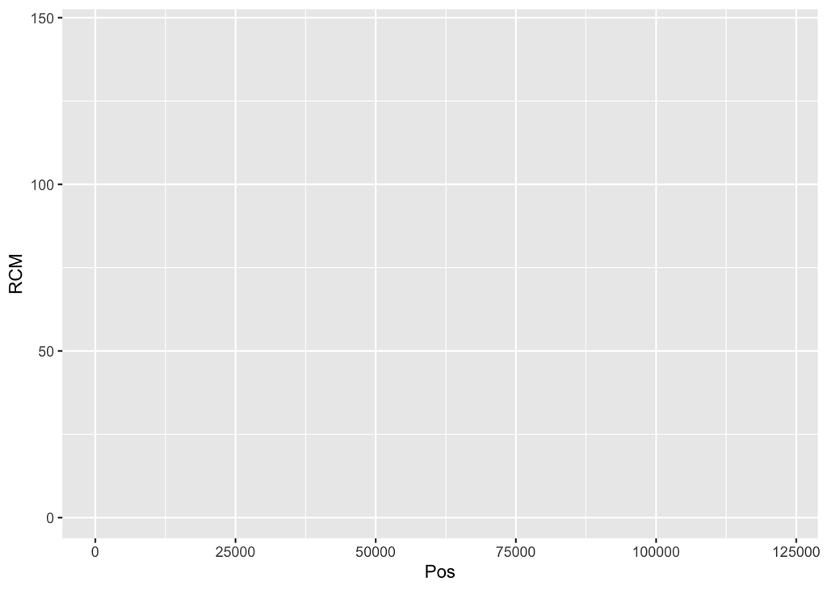

```r
singlePlot
```

Oops. That gave us a blank plot. This is a common mistake (and source of frustration) with ggplot. In the native plot function in R, simply defining the x- and y-variables is sufficient to generate a plot. For example:

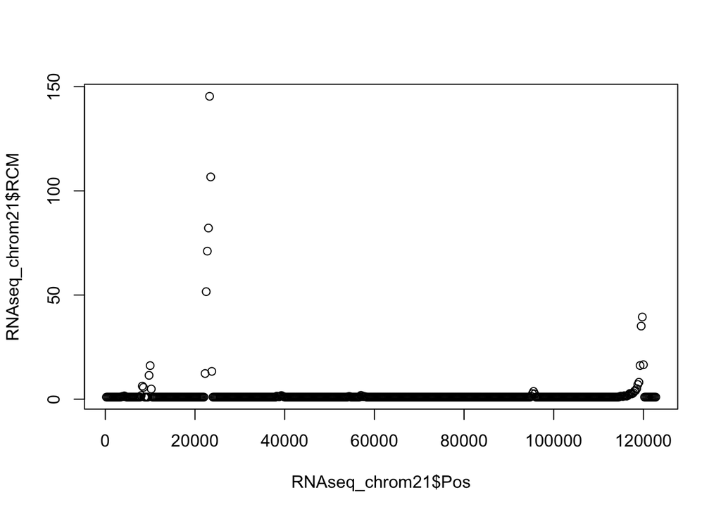

```r
plot (RNAseq_chrom21$Pos, RNAseq_chrom21$RCM)
```

But this is not sufficient for ggplot. In this case, we have only done the aesthetic mappings to associate the variables `Pos` and `RCM` in the dataset with the X and Y positions, respectively. To visualize the data, we need to specify at least one geometry. Let’s generate a scatter plot by adding the `geom_point()` statement. This will inherit the mapping information from the `aes()` arguments in the main `ggplot` call.

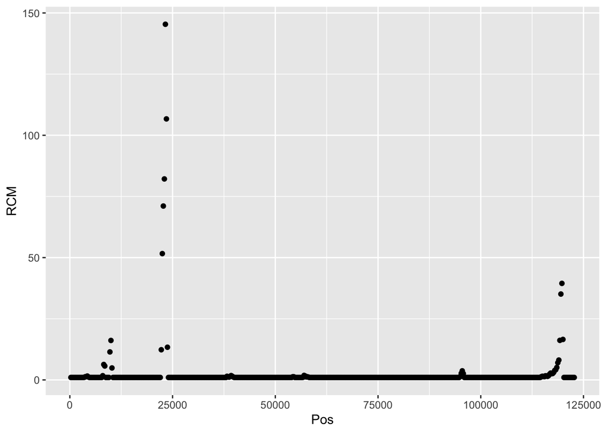

```r
singlePlot = ggplot (data=RNAseq_chrom21, aes(x=Pos, y=RCM)) + geom_point()

singlePlot
```

Now, let’s distinguish between “genic” and “intergenic” regions as defined in the input file. We can add to our aesthetic mappings by including a `color` statement and associating with the `Region` variable in our data set..

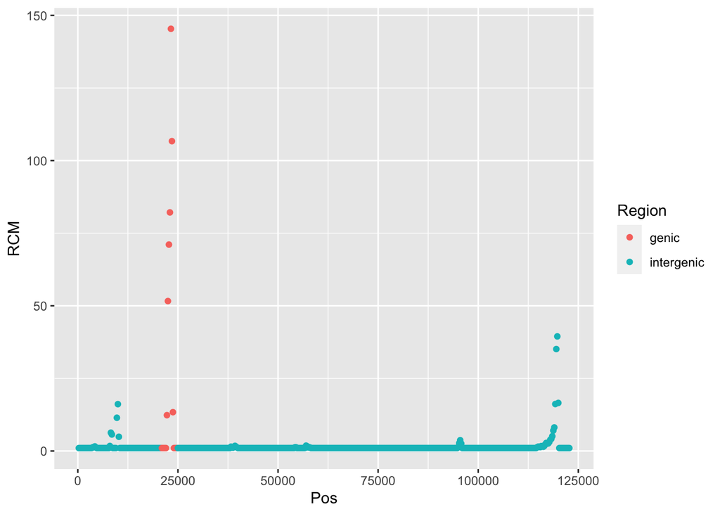

```r
singlePlot = ggplot (data=RNAseq_chrom21, aes(x=Pos, y=RCM, color=Region)) + geom_point()

singlePlot
```

If you are not fond of the color scheme, you can modify it by adding an additional statement to the existing plot.

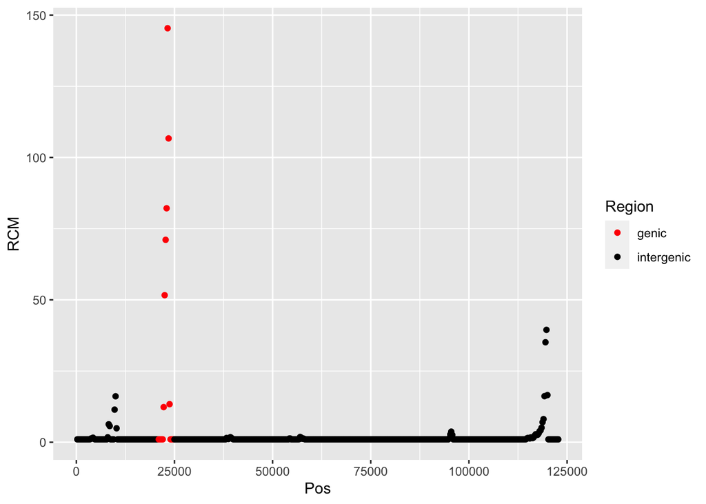

```r
singlePlot + scale_color_manual(values=c("red", "black"))
```

Now we see that the region of highest expression is an annotated gene. But there are also highly expressed regions in uncharacterized intergenic sequence. Note that we could have used an alternative color scheme for our points. For example, instead of putting them into two categories (genic and intergenic) we could have used a “heat map” to color them based on a continuous variable such as `Enrichment` (see above for description of the `Enrichment` data). Let’s try that by defining a new plot entirely.

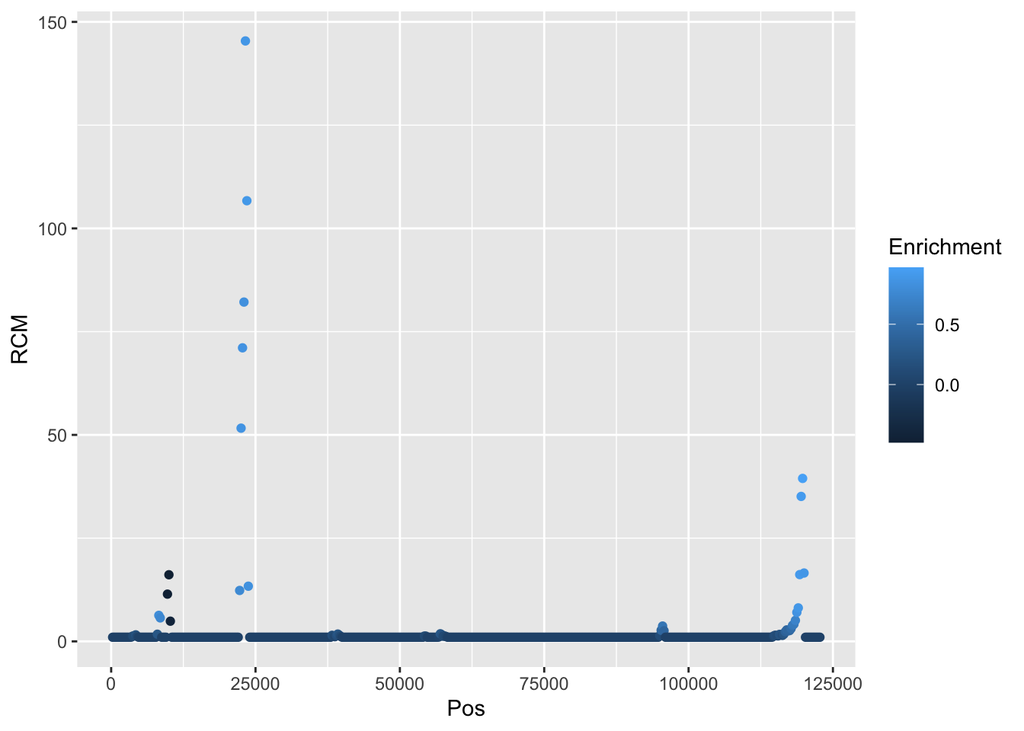

```r
singlePlot2 = ggplot (data=RNAseq_chrom21, aes(x=Pos, y=RCM, color=Enrichment)) + geom_point()

singlePlot2
```

Now the shading of the points reflects the extent to which the transcripts are enriched in the mitochondria relative to the total-cellular fraction (lighter blue indicates more enrichment). If you don’t like the default color scheme, the `viridis` package offers a nice palette for heat maps (and note that this palette is better perceived by color-blind individuals than classic red/green heat map scales). We can amend our stored plot as follows. Note that if you don’t have the `viridis` package installed you can add it with `install.packages("viridis")`.

```r
library(viridis)
```

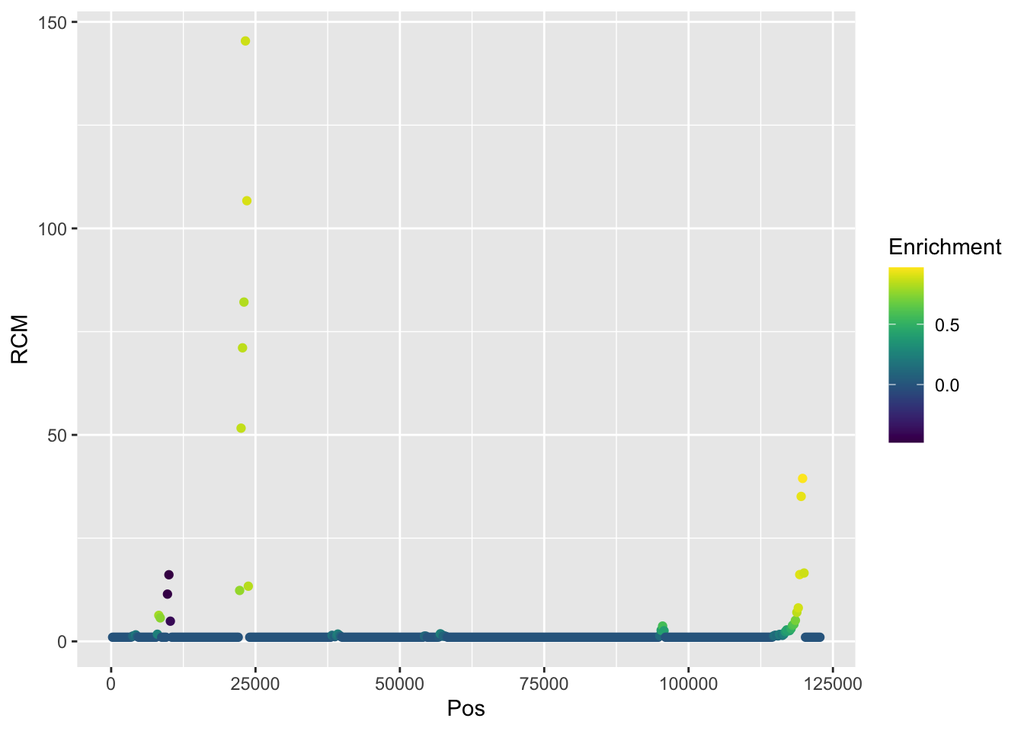

```r
singlePlot2 + scale_color_viridis()
```

Now, we clearly see that most of the highly expressed regions are also greatly enriched in mitochondrial RNA samples. But that is not the case for one region (three purple points around position 10 kb). This region is likely a foreign chloroplast or nuclear gene that has been inserted into the mitochondrial genome but not actually highly expressed in the mitochondria themselves.

Above, we made a modification to a stored plot (`singlePlot2`). But we can also build up the full code in one statement, and you do not always need to store your plot in a vairable. Just running the code without assigning it to a variable will automatically display the results. Let’s just enter the full code for the next step. It is often best to display expression data on a log-scale, so let’s make a further modification to the y-axis scale.

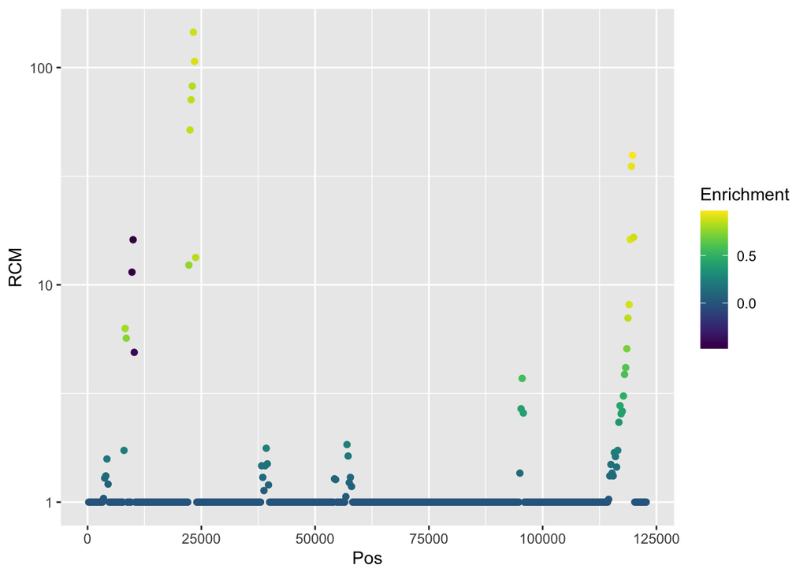

```r
ggplot (data=RNAseq_chrom21, aes(x=Pos, y=RCM, color=Enrichment)) + geom_point() + scale_color_viridis() + scale_y_log10()
```

It’s always good to label your axes clearly. Let’s change the axes labels to something a little less cryptic. Note that this involves editing the `theme` of the plot (i.e., the non-data text and lines that appear on the plot). This can be done with the `theme` function, but `xlab` and `ylab` are shortcuts for just setting the axes labels.

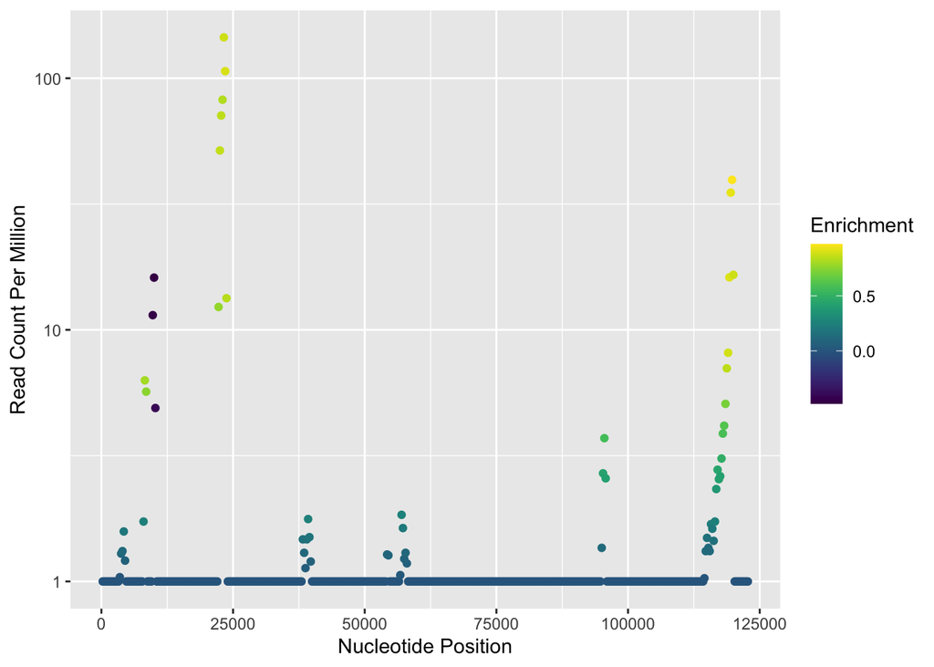

```r
ggplot (data=RNAseq_chrom21, aes(x=Pos, y=RCM, color=Enrichment)) + geom_point() + scale_color_viridis() + scale_y_log10() + xlab("Nucleotide Position") + ylab("Read Count Per Million")
```

Hmmm. When we scale this up to a multipanel figure, we might not be able to write out those long number for the x-axis positions. Let’s convert those to kb by changing our x mapping from `Pos` to `Pos/1000` and updating our `xlab` accordingly to indicate that the scale is in kb.

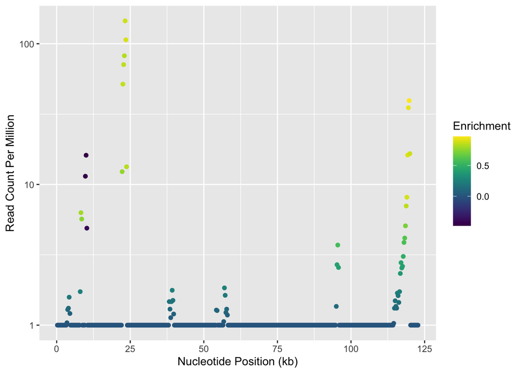

```r
ggplot (data=RNAseq_chrom21, aes(x=Pos/1000, y=RCM, color=Enrichment)) + geom_point() + scale_color_viridis() + scale_y_log10() + xlab("Nucleotide Position (kb)") + ylab("Read Count Per Million")
```

Speaking of space, having a smaller point size might help us down the line. You can map `size` to a variable with `aes()` if you want it to reflect some aspect of your dataset, but you can also set it to a constant as an attribute of `geom_point`. Let’s reduce the point size by adding `size=0.5` to our `geom_point()` call. This might be smaller than we’d like for a single plot like this, but it will help reduce overlap when we build up to a dense multipanel plot.

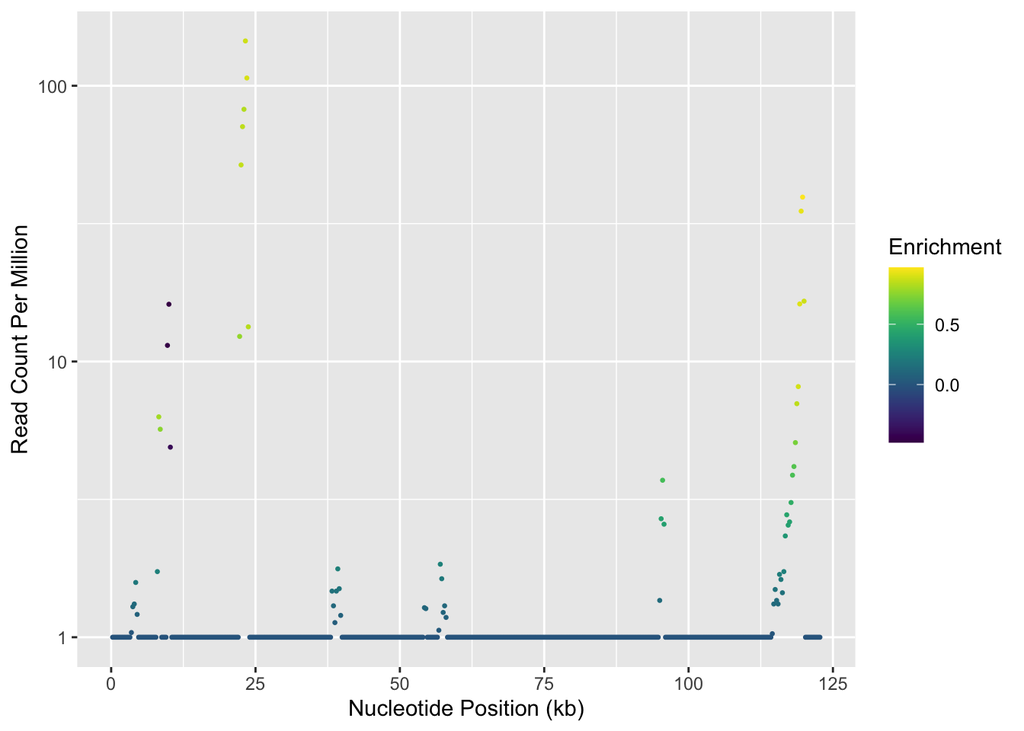

```r
ggplot (data=RNAseq_chrom21, aes(x=Pos/1000, y=RCM, color=Enrichment)) + geom_point(size=0.5) + scale_color_viridis() + scale_y_log10() + xlab("Nucleotide Position (kb)") + ylab("Read Count Per Million")
```

One last tweak to our individual plot. There are numerous `theme` elements you can adjust individually, but ggplot also provides pre-packaged themes. For example, `theme_bw()` and `theme_classic()` can provide a bit of a cleaner overall look than the default theme and its gray plot background. Let’s add `+ theme_bw()` to update our theme.

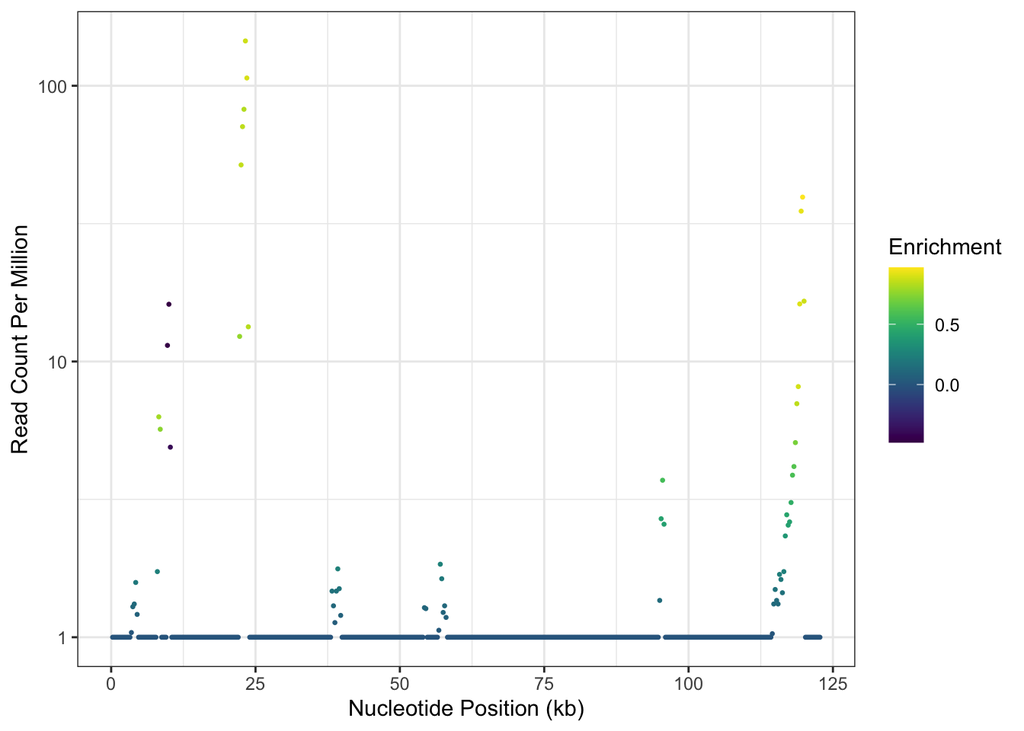

```r
ggplot (data=RNAseq_chrom21, aes(x=Pos/1000, y=RCM, color=Enrichment)) + geom_point(size=0.5) + scale_color_viridis() + scale_y_log10() + xlab("Nucleotide Position (kb)") + ylab("Read Count Per Million") + theme_bw()
```

### 5. Generate a multipanel figure showing read depth across each of the 63 chromosomes

We have just developed code to plot read depth along the length of a single chromosome. But what about the other 62 chromosomes in this genome? It turns out that with very small additions and modifications to our existing code, we can generate a single figure with a separate panel for each and everyone of the chromosomes. Compare the following code for plotting data from all 63 chromosomes to what we just ran above for a single chromosome.

```r
ggplot (data=RNAseq, aes(x=Pos/1000, y=RCM, color=Enrichment)) + geom_point(size=0.5) + scale_color_viridis() + scale_y_log10() + xlab("Nucleotide Position (kb)") + ylab("Read Count Per Million") + theme_bw() + scale_x_continuous (breaks=c(0,75,150)) + facet_wrap(~Chrom, nrow=7)
```

Try running the above code and storing it to a variable called “multiPlot”. Then print it by typing `multiPlot`.

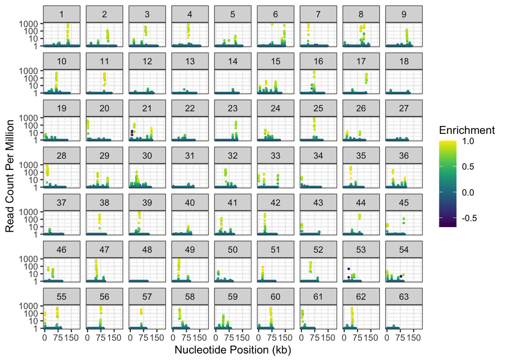

There are multiple ways to output a figure to a PDF. One is use the `pdf` and `dev.off` commands as follows (you can also explore the `ggsave` command as well as exporting from the viewer from RStudio).

```r
pdf ("multiPlot.pdf")
multiPlot
dev.off()
```

To verify that you have produced a publication-quality multipanel figure, open the PDF and check it out!

## Additional resources for ggplot

- [ggplot documentation](https://ggplot2.tidyverse.org/index.html)
- [Datacamp](https://learn.datacamp.com/): Check out the courses on Introduction to Data Visualization with ggplot2, Intermediate Data Visualization with ggplot2, and Visualization Best Practices in R.
- [Claus Wilke’s Data Visualization Course at U Texas](https://wilkelab.org/SDS375/syllabus.html)
- [R for Data Science](https://r4ds.had.co.nz/)

## Assignment

Further develop your ggplot skills by generating your own plot with the following guidelines.

- Ideally use a dataset of your own. But if you do not have a suitable dataset, you can obtain one online or use one of built-in datasets in R (there are a bunch of these like `iris` and `mtcars`).
- Utilize the `facet_grid` command or the `facet_wrap` command to generate multiple panels in the plot.
- Inlcude at least two different geoms. In the preceding exercise, we only used `geom_point()`. But it is common to layer multiple geoms. For example, this could be points layered on top of a box-plot or a rug plot underlying a density curve or a linear model fit to a scatter plot. If you are already experienced with ggplot, try to stretch your skillset by using geoms you don’t usually work with. There are [so many to choose from the in the ggplot base package](https://ggplot2.tidyverse.org/reference/#section-geoms) and even more available in add-on packages such as [ggridges](https://cran.r-project.org/web/packages/ggridges/vignettes/introduction.html).
- Make sure your plot is cleanly presented and appropriately labeled by modifying the corresponding [elements of the theme](https://ggplot2.tidyverse.org/reference/theme.html).
- For the best learning experience, try to come up with your own vision first and then figure out how to implement it, rather than finding an example online and attempting to clone it.

Submit your **completed plot and R code** via Canvas.